## Loading and preprocessing the data

```r
library(ggplot2)
library(plyr)
library(scales)
library(Hmisc)
```

1. Load the data (i.e. read.csv())

```r
activitydata <- read.csv('activity.csv')
```

2. Process/transform the data (if necessary) into a format suitable for your analysis

```r
activitydata$day <-  ifelse(as.POSIXlt(activitydata$date)$wday %in% c(0,6), 'weekend', 'weekday')
```

## What is mean total number of steps taken per day?

1. Calculate the total number of steps taken per day

```r
stepsperday <- tapply(activitydata$steps, activitydata$date, sum, na.rm=TRUE)
```

2. Make a histogram of the total number of steps taken each day

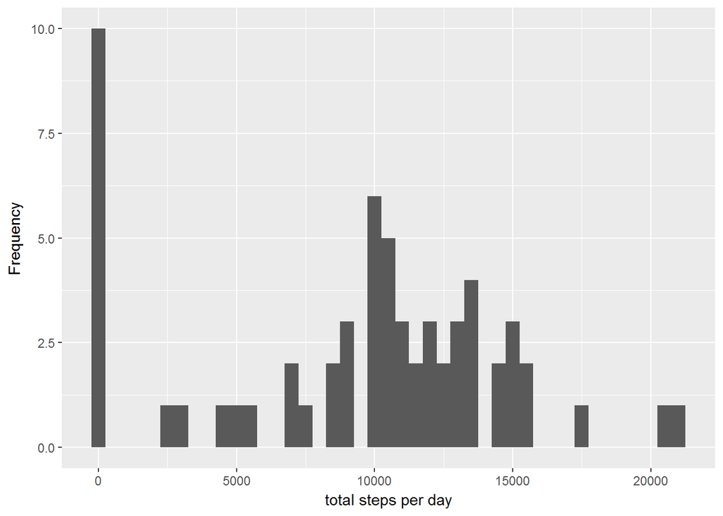

```r
qplot(stepsperday, xlab='total steps per day', ylab='Frequency', binwidth=500)
```

3. Calculate and report the mean and median total number of steps taken per day

```r
Mean_stepsperday <- mean(stepsperday)
Median_stepsperday <- median(stepsperday)
Mean_stepsperday
```

```
## [1] 9354.23
```

```r
Median_stepsperday
```

```
## [1] 10395
```

## What is the average daily activity pattern?

1. Make a time series plot (i.e. type = “l”) of the 5-minute interval (x-axis) and the average number of steps taken, averaged across all days (y-axis)

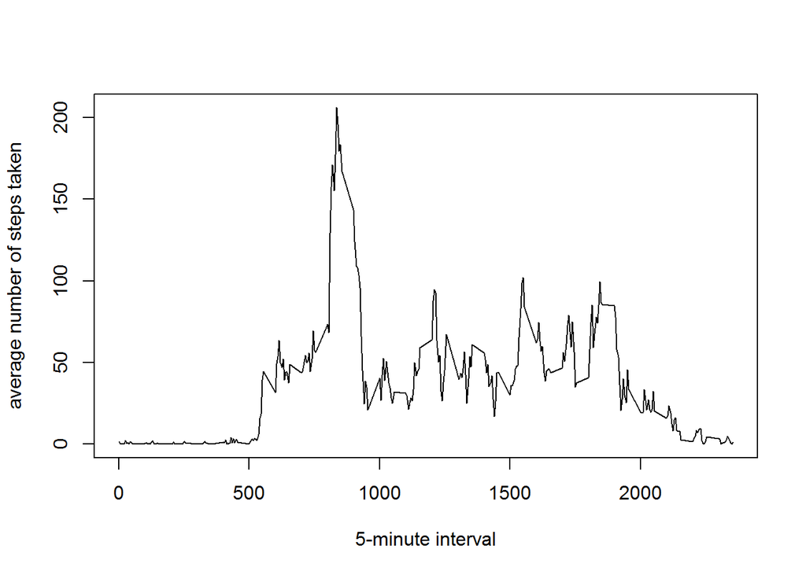

```r
stepsinterval <- aggregate(steps~interval, data=activitydata, mean, na.rm=TRUE)
plot(steps~interval, data=stepsinterval, type="l", xlab="5-minute interval", ylab = "average number of steps taken")
```

2. Which 5-minute interval, on average across all the days in the dataset, contains the maximum number of steps?

```r
MAXsteps <- stepsinterval[which.max(stepsinterval$steps),]$interval
MAXsteps
```

```
## [1] 835
```